# Persephone: An Agent-Based Model for Bioarchaeology

6. Read the simulated data into the workspace from the files that were just written. This function is useful for executing analyses and visualizing output in later work sessions, after running the model.
7. Reshape the data just read into the work space, changing it from nested lists to a single data frame.

```r
#### This chunk contains some functions to optimize model workflow so that the user can execute and systematically save a full sweep of specified parameter values. ####

# Function to generate root output directory name of folder in which to store data produced from a single set of model parameter values.
generate_output_directory <- function(params) {
  mortality_regime_number <- gregexpr("[0-9]+", params[["mortality_regime"]]$name)
  mortality_regime_abbrev <- paste0("CDW", regmatches(params[["mortality_regime"]]$name, mortality_regime_number))
  paste0(here::here("Known Unknowns", "Data for Main Analysis",
                  mortality_regime_abbrev))
}

# Function to create a list of the default parameters that are (likely) to remain stable across model runs.
# Each of these parameter values can be overwritten to vary model inputs, but these are the values used in the main text of the paper.
get_default_params = function() {
  params = list()
  params["cohort_size"] = 1000
  params["lesion_formation_rate"] = 0.05
  params["formation_window_opens"] = 0
  params["formation_window_closes"] = 10
  params[["mortality_regime"]] = CoaleDemenyWestF5
  params["mortality_risk_type"] = "proportional"
  params["relative_mortality_risk"] = 1
  return(params)
}


#### Functions to run the model and save model parameters and simulated data ####

### Run the model a single time, creating a named output directory and a generating and saving a random seed.
# This function creates an 'output directory' folder and inside it, it saves
# the random seed (.csv file)
# the list of parameters used in the model (.json file)
# the data frame of imaginary people and their language data generated by the model (.csv file)
run_model_single = function(params, output_directory, seed = NA) {

  #Create a uniquely named output directory to store the output from this model run.
  if (dir.exists(output_directory)) {
    print("Warning: output directory already exists! Skipping simulation to avoid overwriting data.")
    return()
  } else {
    dir.create(output_directory, recursive=TRUE)
  }

  #If no seed is set, set a unique random seed
  if (is.na(seed)) {
    seed = as.numeric(format(Sys.time(), "%OS6"))*1000000 #choose milliseconds of current time as seed
  }
  set.seed(seed)
  # in the output directory for this model run, keep a record of the random seed used so that the exact output of this run can be replicated.
  write(seed, file = file.path(output_directory, "seed.csv"))


  #Write input parameters to output_directory
  write(toJSON(params, pretty=TRUE), file=file.path(output_directory, "params_used.json"))

  #Run model
  output = do.call(Simulate_Cemetery, params)

  #Write model output
  write.csv(output$individual_outcomes, file=file.path(output_directory, "sim_cemetery.csv"), row.names=FALSE)
  write.csv(output$survivors, file=file.path(output_directory, "sim_survivors.csv"), row.names=FALSE)


  #For convenience, also return output here
  return(output)
}




### Function to run and save a specified number of repeated model runs that use identical parameter values.

# User designates the root output directory, parameter values, and the number of runs (numreps).
# Each run will be saved in its own named folder, which will contain the files created by run_model_single() described above
run_model_reps = function(params, root_output_directory, numreps=10) {
  for (rep in 1:numreps) {
    output_directory = file.path(root_output_directory, paste0("rep=", rep))
    run_model_single(params, output_directory)
  }
}



### Function to perform a systematic sweep across specified values of a single parameter, holding all other values constant.

# This function wraps around the previous two functions. It produces a folder for each unique set of parameter values,
# named for the parameter being swept, and its value in this set of runs. Inside the folder is a folder for each run (rep), containing the value of the random seed, the .json file of parameter values, and the output of the model run.

#targetParam: the name of the parameter you want to sweep over
#targetParamValues: the values you want to sweep over (list or vector)
run_model_sweep = function(base_params, root_output_directory, target_param, target_param_values, numreps=10) {
  for (iVal in 1:length(target_param_values)) {
    # for each unique value of the target parameter, name the folder to hold all runs of the model that uses this parameter value.
    param_set_output_directory = file.path(root_output_directory, paste0(target_param, "=", target_param_values[iVal]))
    params = copy(base_params)
    # overwrite the default parameter value with the current value of the target parameter
    params[target_param] = target_param_values[iVal]

    run_model_reps(params, param_set_output_directory, numreps=numreps)
  }

  sweep_data = list()
  sweep_data["target_param"] = target_param
  sweep_data[["target_param_values"]] = target_param_values
  write(toJSON(sweep_data, pretty=TRUE), file=file.path(root_output_directory, "sweep_data.json"))
}





### Function to read in the simulated data. This creates a nested list.
read_model_sweep = function(root_output_directory, target_param, target_param_values, data_file) { # data_file is either "sim_cemetery.csv" or "sim_survivors.csv"
  sweep_results = list()

  # for each value in the parameter being swept
  for (param_value in target_param_values) {
    param_dir = file.path(root_output_directory, paste0(target_param,"=", param_value)) # identify the directory where the output for that scenario is stored
    rep_dirs = list.dirs(param_dir, recursive = FALSE, full.names = TRUE) # identify the file paths for all the iterations/runs of that scenario

    # extract the output .csv file from each run
    rep_outputs = lapply(rep_dirs, function(rep_dir) {
      output_file = file.path(rep_dir, data_file)
      if (file.exists(output_file)) {
        return(read_csv(output_file))
      } else {
        print("file does not exist")
        return(NULL)
      }
    })

    # and save it as an entry in the sweep_results list, named with the target parameter value for this set of runs.
    sweep_results[[paste0(target_param,"=",param_value)]] = rep_outputs
  }

  # return a list of lists: one for each value of the target parameter, containing a list of model output data frames from the output.csv files
  return(sweep_results)
}



### Function to reshape data from lists to a single data frame, for easier plotting and analysis ###
data_to_data_frame <- function(cemetery_data_list, target_param, target_param_values){
  worlds <- data.frame()
  for(scenario in seq_along(target_param_values)){
    for(rep in seq_along(cemetery_data_list[[scenario]])){
      cemetery_data_list[[scenario]][[rep]]$rep <- rep # Count the iterations
    }
    out <- do.call("rbind", cemetery_data_list[[scenario]]) # Compile the list of iterated runs into a single data frame
    out[target_param] <- target_param_values[scenario]  # Add mortality regime name
    worlds <- bind_rows(worlds, out)  # Combine all scenarios across the parameter sweep into a single data frame
    worlds$mortality <- "Coale Demeny West F5"  # Add mortality regime name
  }
  return(worlds)
}
```

**Run the model to simulate data for the main analysis**

- 100 runs of the model with each unique combination of parameter values.
- Every parameter is held constant across model runs **except** for relative_mortality_risk.  
  * This is either 1 (no difference in relative mortality risk when a lesion is present)  
  * or 2 (mortality risk doubles when a lesion is present)

**This should result in simulated data on lesion status and age at death for 200,000 individuals.**.

```r
# set default parameter values
params = get_default_params()
# run 100 iterations of the model with the null (risk-free lesions) scenario

generate_output_directory(params)
```

```
## [1] "/Users/amyanderson/Desktop/Paradox Model/Persephone ABM for Bioarchaeology/Known Unknowns/Data for Main Analysis/CDW5"
```

The simulated data for the first set of parameter values (relative mortality risk = 1) will be saved in this named folder.

```r
# (hide results because once the directory structure for the simulated data already exists, this function has a safety catch that produces hundreds of repeated warnings about skipping each directory name to avoid overwriting the data that are already in there.)
# run the model with scenarios for risk-free lesions (relative_mortality_risk = 1) and risk-doubling lesions (relative_mortality_risk = 2)

 run_model_sweep(params,
               root_output_directory = generate_output_directory(params),
               target_param = "relative_mortality_risk",
               target_param_values = c(1, 2),
               numreps = 100)
```

After running this chunk, the simulated data for each year of the living cohort and its resulting skeletal assemblage, the parameter values for each run of the model and the random seed should all be saved in a nested file structure stored in the directory that was named by the generate_output_directory() command, which organizes folders by the unique combination of parameter values.

**We can now read the simulated data back into the workspace for analysis.**

```r
##### Read in the simulated cemetery data from the newly made files generated by the run_model_sweep() command ####
sim_data = read_model_sweep(
  root_output_directory = generate_output_directory(params),
  target_param = "relative_mortality_risk",
  target_param_values = c(1, 2),
  data_file = "sim_cemetery.csv" # specify the file with cemetery/mortality data
  ) %>%
  # reshape data from a nested list to a single data frame.
  data_to_data_frame(target_param = "relative_mortality_risk", target_param_values = c(1,2)) %>%
  mutate(scenario = if_else(relative_mortality_risk == 1, "Risk-free", "Risk-doubled"), # Add a column that denotes the modeling scenario, corresponding with the value for lesion-associated relative mortality risk.
  # Create age intervals (Archaeologically standard intervals for age at death estimated from skeletal features) matched to precise ages at death for simulated individuals.
         Age_Interval = factor(case_when(
    Age < 2 ~ "0-1",
    Age >= 2 & Age < 6 ~ "2-5",
    Age >= 6 & Age < 10 ~ "6-9",
    Age >= 10 & Age < 15 ~ "10-14",
    Age >= 15 & Age < 20 ~ "15-19",
    Age >= 20 & Age < 30 ~ "20-29",
    Age >= 30 & Age < 40 ~ "30-39",
    Age >= 40 & Age < 50 ~ "40-49",
    Age >= 50 & Age < 60 ~ "50-59",
    Age >= 60 ~ "60+"
  ), levels = c("0-1","2-5","6-9","10-14","15-19","20-29","30-39","40-49","50-59","60+")),
  mortality = factor(mortality),
  relative_mortality_risk = as.factor(relative_mortality_risk)) %>%
  rename(relative_risk = relative_mortality_risk)# shortened the variable name for data visualization in this markdown file.
```

#### *Preview data from Scenario 1*

```r
# preview the first 20 rows of the resulting data frame.
# (Omit the Age_Interval variable, to keep all columns on the same row for ease of reading)
head(sim_data %>% select(-Age_Interval), n = 20L)
```

```
##    agent_id Age Lesion rep relative_risk            mortality  scenario
## 1         1   1      0   1             1 Coale Demeny West F5 Risk-free
## 2         2  25      1   1             1 Coale Demeny West F5 Risk-free
## 3         3  64      0   1             1 Coale Demeny West F5 Risk-free
## 4         4  76      0   1             1 Coale Demeny West F5 Risk-free
## 5         5  58      0   1             1 Coale Demeny West F5 Risk-free
## 6         6  12      1   1             1 Coale Demeny West F5 Risk-free
## 7         7  75      1   1             1 Coale Demeny West F5 Risk-free
## 8         8   1      0   1             1 Coale Demeny West F5 Risk-free
## 9         9  26      0   1             1 Coale Demeny West F5 Risk-free
## 10       10   1      0   1             1 Coale Demeny West F5 Risk-free
## 11       11  25      1   1             1 Coale Demeny West F5 Risk-free
## 12       12  67      1   1             1 Coale Demeny West F5 Risk-free
## 13       13  28      1   1             1 Coale Demeny West F5 Risk-free
## 14       14   2      1   1             1 Coale Demeny West F5 Risk-free
## 15       15  55      0   1             1 Coale Demeny West F5 Risk-free
## 16       16  74      0   1             1 Coale Demeny West F5 Risk-free
## 17       17   1      0   1             1 Coale Demeny West F5 Risk-free
## 18       18  61      1   1             1 Coale Demeny West F5 Risk-free
## 19       19  26      0   1             1 Coale Demeny West F5 Risk-free
## 20       20  17      1   1             1 Coale Demeny West F5 Risk-free
```

#### *Preview data from Scenario 2*

```r
head(sim_data %>% filter(scenario == "Risk-doubled") %>% select(-Age_Interval), n = 20L)
```

```
##    agent_id Age Lesion rep relative_risk            mortality     scenario
## 1         1  15      0   1             2 Coale Demeny West F5 Risk-doubled
## 2         2   2      1   1             2 Coale Demeny West F5 Risk-doubled
## 3         3   1      0   1             2 Coale Demeny West F5 Risk-doubled
## 4         4  48      0   1             2 Coale Demeny West F5 Risk-doubled
## 5         5  63      0   1             2 Coale Demeny West F5 Risk-doubled
## 6         6  43      0   1             2 Coale Demeny West F5 Risk-doubled
## 7         7   1      0   1             2 Coale Demeny West F5 Risk-doubled
## 8         8  62      0   1             2 Coale Demeny West F5 Risk-doubled
## 9         9  40      1   1             2 Coale Demeny West F5 Risk-doubled
## 10       10   2      0   1             2 Coale Demeny West F5 Risk-doubled
## 11       11   4      0   1             2 Coale Demeny West F5 Risk-doubled
## 12       12   8      1   1             2 Coale Demeny West F5 Risk-doubled
## 13       13   2      1   1             2 Coale Demeny West F5 Risk-doubled
## 14       14  17      1   1             2 Coale Demeny West F5 Risk-doubled
## 15       15   4      0   1             2 Coale Demeny West F5 Risk-doubled
## 16       16  64      1   1             2 Coale Demeny West F5 Risk-doubled
## 17       17   2      1   1             2 Coale Demeny West F5 Risk-doubled
## 18       18   1      1   1             2 Coale Demeny West F5 Risk-doubled
## 19       19  43      1   1             2 Coale Demeny West F5 Risk-doubled
## 20       20   1      0   1             2 Coale Demeny West F5 Risk-doubled
```

```r
### Now read in the files from the recent model sweep that contain data on the surviving members of the cohort at each time step of the model run
sim_survivors = read_model_sweep(
  root_output_directory = generate_output_directory(params),
  target_param = "relative_mortality_risk",
  target_param_values = c(1, 2),
  data_file = "sim_survivors.csv" # specify the file with data on the living members of the cohort.
  ) %>%
  # reshape data from a nested list to a single data frame.
  data_to_data_frame(target_param = "relative_mortality_risk", target_param_values = c(1,2)) %>%
  mutate(scenario = if_else(relative_mortality_risk == 1, "Risk-free", "Risk-doubled"), # Add a column that denotes the modeling scenario, corresponding with the value for lesion-associated relative mortality risk.
  # Create age intervals (Archaeologically standard intervals for age at death estimated from skeletal features) matched to precise ages at death for simulated individuals.
         Age_Interval = factor(case_when(
    Age < 2 ~ "0-1",
    Age >= 2 & Age < 6 ~ "2-5",
    Age >= 6 & Age < 10 ~ "6-9",
    Age >= 10 & Age < 15 ~ "10-14",
    Age >= 15 & Age < 20 ~ "15-19",
    Age >= 20 & Age < 30 ~ "20-29",
    Age >= 30 & Age < 40 ~ "30-39",
    Age >= 40 & Age < 50 ~ "40-49",
    Age >= 50 & Age < 60 ~ "50-59",
    Age >= 60 ~ "60+"
  ), levels = c("0-1","2-5","6-9","10-14","15-19","20-29","30-39","40-49","50-59","60+")),
  mortality = factor(mortality),
  relative_mortality_risk = as.factor(relative_mortality_risk)) %>%
  rename(relative_risk = relative_mortality_risk)# shortened the variable name for data visualization


# Preview survivor data
head(sim_survivors %>% select(-Age_Interval))
```

```
##   Age Alive Lesion Lesion_perc rep relative_risk            mortality  scenario
## 1   1   811     52         6.4   1             1 Coale Demeny West F5 Risk-free
## 2   2   763     68         8.9   1             1 Coale Demeny West F5 Risk-free
## 3   3   742     98        13.2   1             1 Coale Demeny West F5 Risk-free
## 4   4   729    127        17.4   1             1 Coale Demeny West F5 Risk-free
## 5   5   722    149        20.6   1             1 Coale Demeny West F5 Risk-free
## 6   6   715    179        25.0   1             1 Coale Demeny West F5 Risk-free
```

#### **Create Figure 3**

(Figures 1 and 2 are conceptual diagrams in the main text of the paper.)

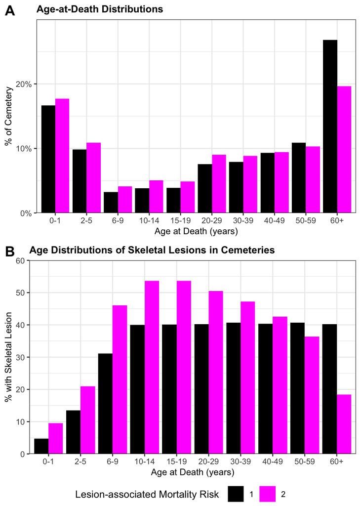

```r
# set plot colors
plot_colors <- c("black", "magenta")

# ---------------------------
# Define a consistent plotting theme for publication-ready figures
# ---------------------------
plot_theme <- theme_bw(base_size = 10) +   # smaller base font size
  theme(
    legend.position = "top",
    legend.text = element_text(size = 8),
    axis.text = element_text(size = 8),
    axis.title = element_text(size = 9),
    plot.title = element_text(size = 10, face = "bold"),
    plot.subtitle = element_text(size = 9)
  )



# Function to calculate percent of individuals at each age in the cemetery with skeletal lesions
lesions_to_percents <- function(cemetery_df, group_vars) { # this function takes a data frame and a c() of named variables.

  # Define age interval labels and their midpoints
  age_lookup <- data.frame(
    Age_Interval = factor(
      c("0-1", "2-5", "6-9", "10-14", "15-19",
        "20-29", "30-39", "40-49", "50-59", "60+"),
      levels = c("0-1", "2-5", "6-9", "10-14", "15-19",
                 "20-29", "30-39", "40-49", "50-59", "60+")
    ),
    interval_midpoint = c(0.5, 3.5, 7.5, 12.5, 17.5,
                          25, 35, 45, 55, 75)
  )

  # Create age intervals and recode mortality levels
  plot_prep_data <- cemetery_df %>%
    mutate(
      Age_Interval = factor(case_when(
        Age < 2 ~ "0-1",
        Age >= 2 & Age < 6 ~ "2-5",
        Age >= 6 & Age < 10 ~ "6-9",
        Age >= 10 & Age < 15 ~ "10-14",
        Age >= 15 & Age < 20 ~ "15-19",
        Age >= 20 & Age < 30 ~ "20-29",
        Age >= 30 & Age < 40 ~ "30-39",
        Age >= 40 & Age < 50 ~ "40-49",
        Age >= 50 & Age < 60 ~ "50-59",
        Age >= 60 ~ "60+"
      ), levels = levels(age_lookup$Age_Interval)),
      mortality = factor(mortality, levels = c("CDW3", "CDW5", "CDW11", "CDW15", "CDW17", "CDW21")),
      mortality = recode(mortality,
                         "CDW3" = "CDW Level 3",
                         "CDW5" = "CDW Level 5",
                         "CDW11" = "CDW Level 11",
                         "CDW15" = "CDW Level 15",
                         "CDW17" = "CDW Level 17",
                         "CDW21" = "CDW Level 21")
    ) %>%
    # Group by specified variables and Age_Interval
    group_by(across(all_of(c(group_vars, "Age_Interval")))) %>%
    summarise(
      Lesion_Percent = sum(Lesion) / n() * 100,
      .groups = "drop"
    ) %>%
    # Join midpoints only where Age_Interval exists
    left_join(age_lookup, by = "Age_Interval")

  return(plot_prep_data)
}



#### Plot age-specific skeletal lesion prevalence in both scenarios ####
# convert individual-level cemetery data to % of individuals with skeletal lesions in each age category
plot_data <- lesions_to_percents(sim_data, group_vars = c("relative_risk", "Age_Interval", "rep"))
plot_data_pooled <- lesions_to_percents(sim_data, group_vars = c("relative_risk", "Age_Interval"))


barplot_lesion_frequency_comparison <- ggplot(plot_data_pooled, aes(x = Age_Interval, y = Lesion_Percent)) +
  geom_col(aes(group = relative_risk, fill = relative_risk), position = "dodge") +
  scale_fill_manual(values = plot_colors) +
  scale_y_continuous(limits = c(0,60), expand = c(0,0) ) +
  labs(x = "Age at Death (years)", y = "% with Skeletal Lesion") +
  plot_theme +
  theme(legend.position = "none") +
  ggtitle("Age Distributions of Skeletal Lesions in Cemeteries")

#### Plot Age at death distributions in both scenarios ####
# Bar plot (more familiar for archaeologists)
barplot_sample_age_distributions <- sim_data %>%
  group_by(relative_risk, Age_Interval) %>%
  summarise(prop = n() / 100000, .groups = "keep") %>%
ggplot(aes(x = Age_Interval, y = prop)) +
  geom_col(aes(group = relative_risk, fill = relative_risk), position = "dodge") +
  scale_fill_manual(values = plot_colors) +
  scale_y_continuous(labels = scales::percent, limits = c(0,.3), expand = c(0,0) ) +
  labs(x = "Age at Death (years)", y = "% of Cemetery", fill = "Lesion-associated Mortality Risk") +
  plot_theme +
  theme(legend.position = "bottom") +
  ggtitle("Age-at-Death Distributions")

legend <- get_legend(barplot_sample_age_distributions)

barplot_sample_age_distributions <- barplot_sample_age_distributions +
  theme(legend.position = "none")

barplots <- plot_grid(barplot_sample_age_distributions, barplot_lesion_frequency_comparison,
                      ncol = 1, labels = "AUTO")

Figure_3 <- plot_grid(barplots, legend, ncol = 1, rel_heights = c(1, 0.05))


# Save the plot as Figure 3
# ggsave(filename = paste0(here("Known Unknowns", "Figures"), "/Figure_3.pdf"),
#   plot = Figure_3,
#   width = 140,
#   units = "mm",
#   dpi = 1200)

# View Figure 3
Figure_3
```

**Figure 3.** Pooled data for all simulated cemeteries. A) Age-at-Death distributions for pooled runs of the model with risk-free skeletal lesions (black) and risk-doubling skeletal lesions (pink). B) Distribution of lesion frequency across ages in pooled runs of risk-free and risk-doubling model scenarios. To better match plots from published bioarchaeological studies, age distributions are presented as bar plots with individuals binned into age categories used for age-at-death estimates in archaeological skeletal series.